# TS_Ind_Assignment_2_CrossValidation

## Exercise

For this exercise use the quarterly number of arrivals to Australia from New Zealand, 1981 Q1 – 2012 Q3, from data set `aus_arrivals`.

```r
# Filter data:
nzarrivals <- aus_arrivals %>% filter(Origin == "NZ")
nzarrivals
```

```
# A tsibble: 127 x 3 [1Q]
# Key:       Origin [1]
   Quarter Origin Arrivals
     <qtr> <chr>     <int>
 1 1981 Q1 NZ        49140
 2 1981 Q2 NZ        87467
 3 1981 Q3 NZ        85841
 4 1981 Q4 NZ        61882
 5 1982 Q1 NZ        42045
 6 1982 Q2 NZ        63081
 7 1982 Q3 NZ        73275
 8 1982 Q4 NZ        54808
 9 1983 Q1 NZ        41030
10 1983 Q2 NZ        56155
# … with 117 more rows
```

### **a. Make a time-plot of your data. Ensure that the grid indicates at least the end of each seasonal period.**

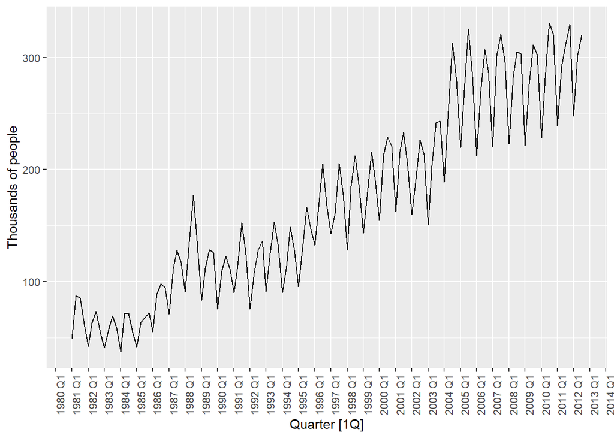

```r
nzarrivals %>%
  autoplot(Arrivals / 1e3) + labs(y = "Thousands of people") +

  # Adjust the x-grid
  scale_x_yearquarter(date_breaks = "1 year",
                      date_minor_breaks = "1 year") +

  # Flip x-labels by 90 degrees
  theme(axis.text.x = element_text(angle = 90))
```

### **b. Create a training set that withholds the last two years of available data for test purposes.**

```r
test_years = 2

train <- nzarrivals %>%
  filter(Quarter <= max(Quarter) - test_years*4)

train
```

```
# A tsibble: 119 x 3 [1Q]
# Key:       Origin [1]
   Quarter Origin Arrivals
     <qtr> <chr>     <int>
 1 1981 Q1 NZ        49140
 2 1981 Q2 NZ        87467
 3 1981 Q3 NZ        85841
 4 1981 Q4 NZ        61882
 5 1982 Q1 NZ        42045
 6 1982 Q2 NZ        63081
 7 1982 Q3 NZ        73275
 8 1982 Q4 NZ        54808
 9 1983 Q1 NZ        41030
10 1983 Q2 NZ        56155
# … with 109 more rows
```

### **c. Fit the following models to your training dataset and create 8-step ahead forecasts:**

- A seasonal naïve method
- An additive STL decomposition separating the seasonally-adjusted component and the seasonal component using `decomposition_model()`. **Is a transformation necessary?.**

```r
First, from the time-plot it is clear that the series is multiplicative,
at least to some extent (variance of seasonal component proportional to the
level of the series). For the `decomposition_model()` using an STL decomposition,
we will need to make the data additive beforehand because STL decomposition
is only applicable to additive data.

Let us therefore explore the value lambda-value for an optimal
box-cox transformation:
```

```r
lambda <- nzarrivals %>%
  features(Arrivals/1e3, features = guerrero) %>%
  pull(lambda_guerrero)

lambda
```

```
[1] 0.3320207
```

```r
Let us now check what this transformation attains by depicting the
transformed data in a time-plot:
```

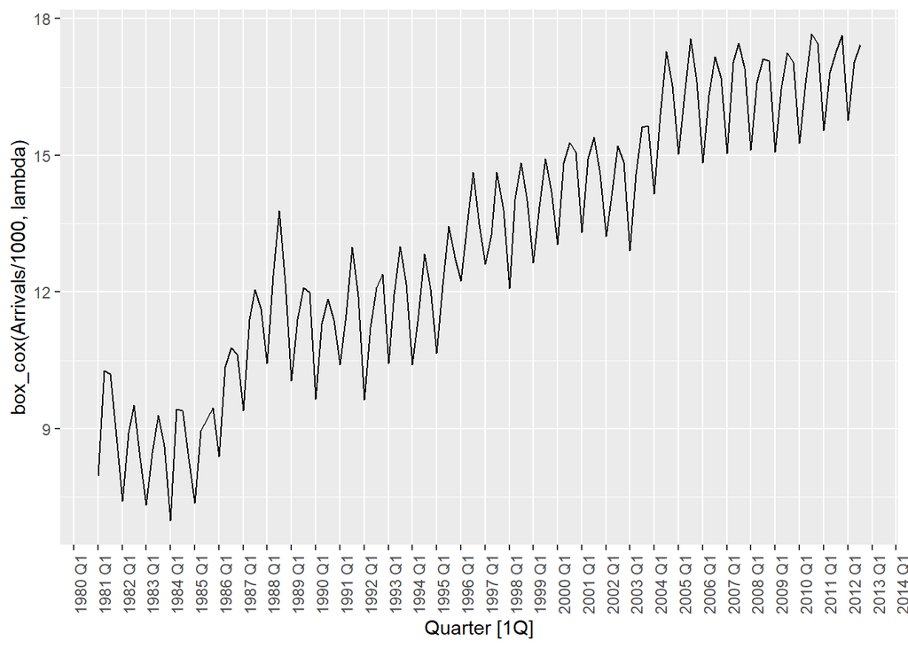

```r
nzarrivals %>%
  autoplot(box_cox(Arrivals/1e3, lambda)) +

  # Adjust the x-grid
  scale_x_yearquarter(date_breaks = "1 year",
                      date_minor_breaks = "1 year") +

  # Flip x-labels by 90 degrees
  theme(axis.text.x = element_text(angle = 90))
```

```r
Indeed the box-cox transformation has rendered the variance of the seasonal
component independent of the level of the time series. Perhaps with the
exception of the year 1988. We will use this transformation.

Let us start by recalling the name of the output components of
an STL decomposition:
```

```r
nzarrivals %>%
  model(
    STL(box_cox(Arrivals/1e3, lambda))
  ) %>%
  components() %>%
  select(Quarter, `box_cox(Arrivals/1000, lambda)`, trend,
         season_year, remainder, season_adjust)
```

```
# A tsibble: 127 x 6 [1Q]
   Quarter `box_cox(Arrivals/1000, lambda)` trend season_year remainder season…¹
     <qtr>                            <dbl> <dbl>       <dbl>     <dbl>    <dbl>
 1 1981 Q1                             7.96  9.63     -1.35     -0.315      9.31
 2 1981 Q2                            10.3   9.43      0.456     0.395      9.82
 3 1981 Q3                            10.2   9.23      0.845     0.123      9.35
 4 1981 Q4                             8.84  9.00      0.0500   -0.209      8.79
 5 1982 Q1                             7.41  8.74     -1.35      0.0151     8.76
 6 1982 Q2                             8.91  8.61      0.448    -0.146      8.46
 7 1982 Q3                             9.52  8.54      0.843     0.142      8.68
 8 1982 Q4                             8.37  8.48      0.0592   -0.174      8.31
 9 1983 Q1                             7.33  8.39     -1.35      0.280      8.67
10 1983 Q2                             8.46  8.38      0.440    -0.359      8.02
# … with 117 more rows, and abbreviated variable name ¹season_adjust
```

```r
When using `decomposition_model()` we need to specify a model for
`season_adjust` (the seasonally adjusted component) and a model for
`season_year` (the seasonal component. In this case we have yearly seasonality).

We will now fit an additive decomposition model using `decomposition_model()`
as well as a seasonal naive component using `SNAIVE()`
```

```r
fit <- train %>%
      model(
        # Model 1: additive decomposition based on STL
        # season_adjust and season_year modelled separately
        decomp = decomposition_model(
                    # Specify decomposition scheme to be used
                    STL(box_cox(Arrivals/1e3, lambda)),
                    # Specify model for the seasonally adjusted component
                    RW(season_adjust ~ drift()),
                    # Specify model for the seasonal component (unnecessary since SNAIVE is default)
                    SNAIVE(season_year)
                    ),

        # Model 2: seasonal naïve component
        seas_naive = SNAIVE(Arrivals)

        )

fit
```

```
# A mable: 1 x 3
# Key:     Origin [1]
  Origin                    decomp seas_naive
  <chr>                    <model>    <model>
1 NZ     <STL decomposition model>   <SNAIVE>
```

```r
We can see that we get an output of a `mable` with 1 row (one time-series
being fitted) and 2 columns (two models used). Let us now produce forecasts
with these models. Since we left out two years in the test data (8 quarters)
we will generate 8-step forecast:
```

```r
fc <- fit %>% forecast(h=8)
fc
```

```
# A fable: 16 x 5 [1Q]
# Key:     Origin, .model [2]
   Origin .model     Quarter           Arrivals   .mean
   <chr>  <chr>        <qtr>             <dist>   <dbl>
 1 NZ     decomp     2010 Q4     t(N(17, 0.14)) 311247.
 2 NZ     decomp     2011 Q1     t(N(16, 0.27)) 238219.
 3 NZ     decomp     2011 Q2     t(N(17, 0.41)) 303048.
 4 NZ     decomp     2011 Q3     t(N(18, 0.55)) 344465.
 5 NZ     decomp     2011 Q4      t(N(17, 0.7)) 324401.
 6 NZ     decomp     2012 Q1     t(N(16, 0.85)) 249350.
 7 NZ     decomp     2012 Q2     t(N(17, 0.99)) 316015.
 8 NZ     decomp     2012 Q3      t(N(18, 1.1)) 358541.
 9 NZ     seas_naive 2010 Q4  N(3e+05, 3.7e+08) 301983
10 NZ     seas_naive 2011 Q1 N(228162, 3.7e+08) 228162
11 NZ     seas_naive 2011 Q2 N(281791, 3.7e+08) 281791
12 NZ     seas_naive 2011 Q3 N(330812, 3.7e+08) 330812
13 NZ     seas_naive 2011 Q4  N(3e+05, 7.5e+08) 301983
14 NZ     seas_naive 2012 Q1 N(228162, 7.5e+08) 228162
15 NZ     seas_naive 2012 Q2 N(281791, 7.5e+08) 281791
16 NZ     seas_naive 2012 Q3 N(330812, 7.5e+08) 330812
```

```r
As expected we obtain 16 rows, since we are producing 8 forecasts
per model (2 models).
```